# Indel Signature InsDel3a

# InsDel3a

(corresponds to 83-type signature C_ID3)

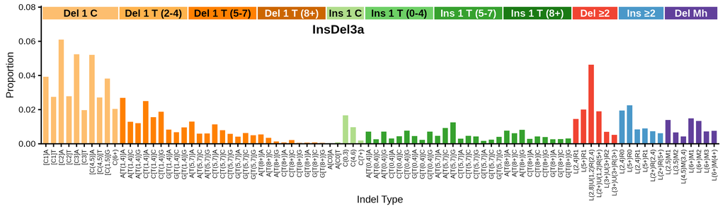

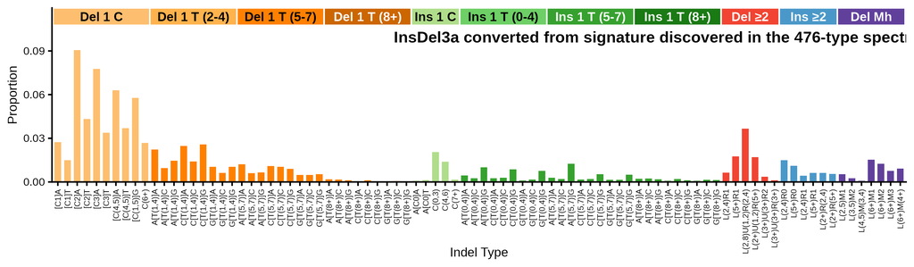

89-type spectrum of the linking tumor CPCT02050436T | cosine similarity to InsDel3a: 0.9738

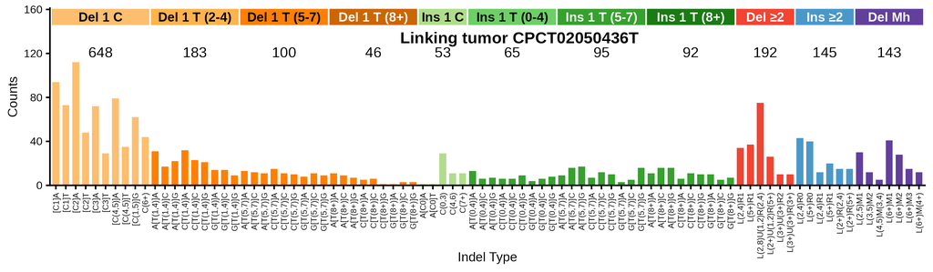

**Click to view decomposition of the linking tumor spectrum**

Partial mutation signature of CPCT02050436T due to InsDel3a

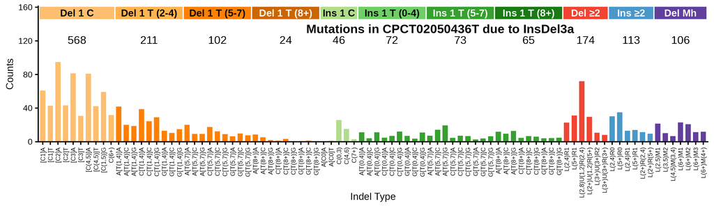

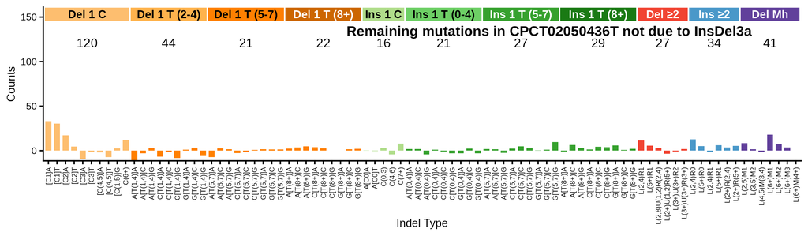

Max neg fraction (maximum allowed negative residual count as fraction of total): 0.06  
N subtract (mutation count assigned to signature): 1554.2  
N residual (mutation count in residual “partial spectrum”): 207.8  
Total negative (sum of negative residual mutation counts): 96.8  
N negative channels (number of channels with negative residual): 26  
P(≥ total negative) (Monte Carlo estimated probability that negative-binomial-sampled spectra from the signature contributing N subtract mutations would produce a total negative count >= the observed Total negative; higher number means not surprising): 0.989

**Per-channel residual breakdown**

| Channel | Spectrum | Sig_Count | Residual | Sig_Prop |
| --- | --- | --- | --- | --- |
| [Del(C):R1]A | 94 | 61.0 | 33 | 0.03923 |
| [Del(C):R1]T | 73 | 42.7 | 30.3 | 0.02746 |
| [Del(C):R2]A | 112 | 94.8 | 17.2 | 0.06100 |
| [Del(C):R2]T | 48 | 43.3 | 4.7 | 0.02785 |
| [Del(C):R3]A | 72 | 81.5 | -9.5 | 0.05241 |
| [Del(C):R3]T | 29 | 30.7 | -1.7 | 0.01973 |
| [Del(C):R(4,5)]A | 79 | 80.8 | -1.8 | 0.05202 |
| [Del(C):R(4,5)]T | 35 | 42.2 | -7.2 | 0.02716 |
| [Del(C):R(1,5)]G | 62 | 59.3 | 2.7 | 0.03815 |
| Del(C):R(6,9) | 44 | 31.8 | 12.2 | 0.02047 |
| A[Del(T):R(1,4)]A | 31 | 41.8 | -10.8 | 0.02692 |
| A[Del(T):R(1,4)]C | 17 | 20.1 | -3.1 | 0.01290 |
| A[Del(T):R(1,4)]G | 22 | 18.8 | 3.2 | 0.01209 |
| C[Del(T):R(1,4)]A | 32 | 38.8 | -6.8 | 0.02496 |
| C[Del(T):R(1,4)]C | 23 | 24.3 | -1.3 | 0.01563 |
| C[Del(T):R(1,4)]G | 21 | 29.2 | -8.2 | 0.01877 |
| G[Del(T):R(1,4)]A | 14 | 13.0 | 1 | 0.00834 |
| G[Del(T):R(1,4)]C | 14 | 10.5 | 3.5 | 0.00676 |
| G[Del(T):R(1,4)]G | 9 | 14.9 | -5.9 | 0.00959 |
| A[Del(T):R(5,7)]A | 13 | 20.3 | -7.3 | 0.01304 |
| A[Del(T):R(5,7)]C | 12 | 9.3 | 2.7 | 0.00598 |
| A[Del(T):R(5,7)]G | 11 | 9.4 | 1.6 | 0.00604 |
| C[Del(T):R(5,7)]A | 15 | 17.6 | -2.6 | 0.01136 |
| C[Del(T):R(5,7)]C | 11 | 12.4 | -1.4 | 0.00799 |
| C[Del(T):R(5,7)]G | 10 | 9.0 | 1 | 0.00582 |
| G[Del(T):R(5,7)]A | 8 | 6.4 | 1.6 | 0.00412 |
| G[Del(T):R(5,7)]C | 11 | 9.7 | 1.3 | 0.00626 |
| G[Del(T):R(5,7)]G | 9 | 7.7 | 1.3 | 0.00497 |
| A[Del(T):R(8,)]A | 11 | 8.5 | 2.5 | 0.00548 |
| A[Del(T):R(8,)]C | 9 | 5.4 | 3.6 | 0.00345 |

[output cut: 59 more lines]

## 476-type representations corresponding to InsDel3a

Extracted 476-type signature corresponding to InsDel3a

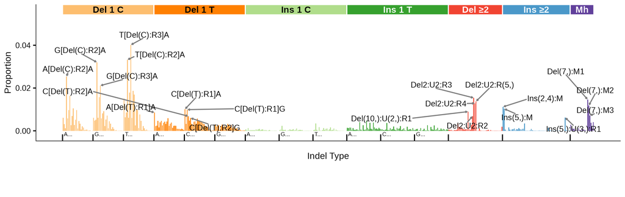

476-type spectrum of the linking tumor CPCT02050436T; cosine similarity to the extracted 476-type signature is 0.8045

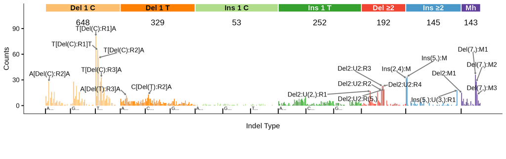

476-type spectrum of best 476-type matching tumor CPCT02040317T; cosine similarity to the extracted 476-type signature is 0.9396

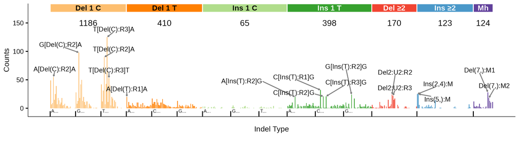

## 83-type signature corresponding to InsDel3a (C_ID3)

**Note**

WARNING: The 83-type signature C_ID3 corresponds to both InsDel3a and InsDel3b. The C_ID3 extraction mainly excluded T deletions in long poly-T contexts that were detected in InsDel3a in extractions in both the 89-type and 476-type classifications, but not in the InsDel3b extractions. Thus, C_ID3 corresponds more closely to InsDel3b than to InsDel3a

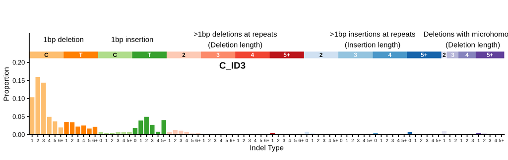

83-type signature converted from signature discovered in the 476-type spectra (using bipartite matching optimization) | cosine similarity to C_ID3: 0.9454

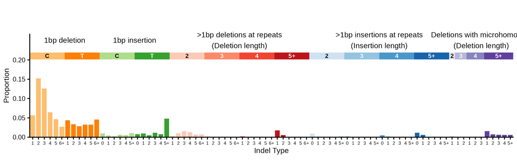

**Click to see flow diagrams: 476-type to 83-type collapse**

These Sankey diagrams show how the 476-type mutation categories are redistributed to 83-type categories using bipartite matching. We only show the diagrams for insertions or deletions of > 1 base because it is for these indels that 476-type categories map to > 1 83-type category.

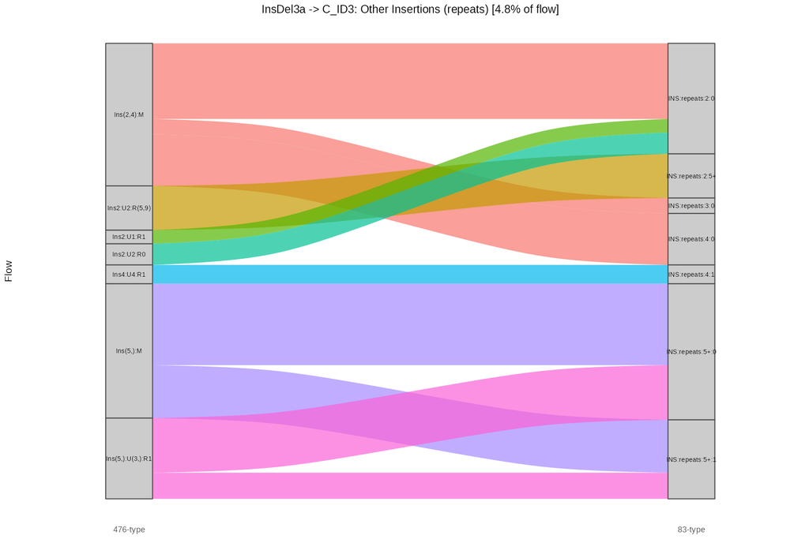

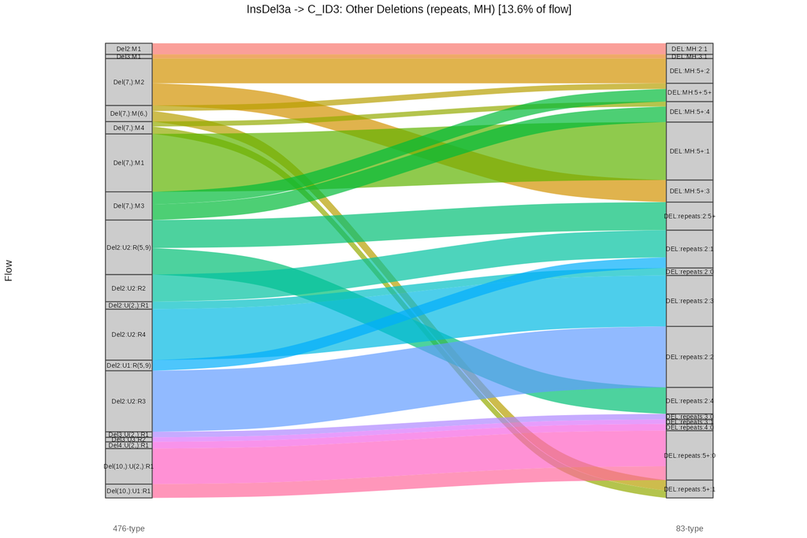

83-type spectrum of the linking tumor CPCT02050436T | cosine similarity to C_ID3: 0.8478

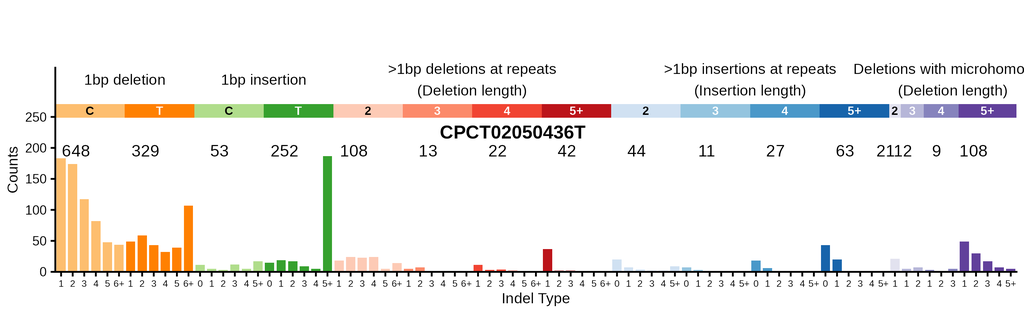

83-type spectrum of best 83-type matching tumor CPCT02020815T | cosine similarity to C_ID3: 0.9973

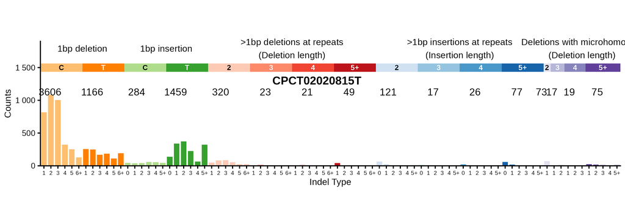

### Similar COSMIC signatures

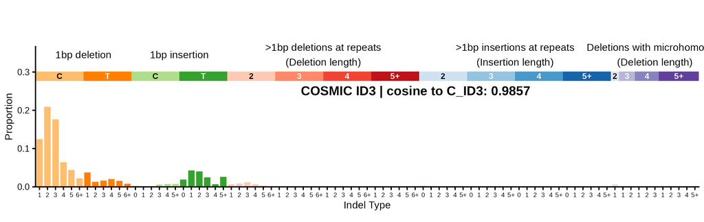

### Similar signatures from Jin et al. 2024

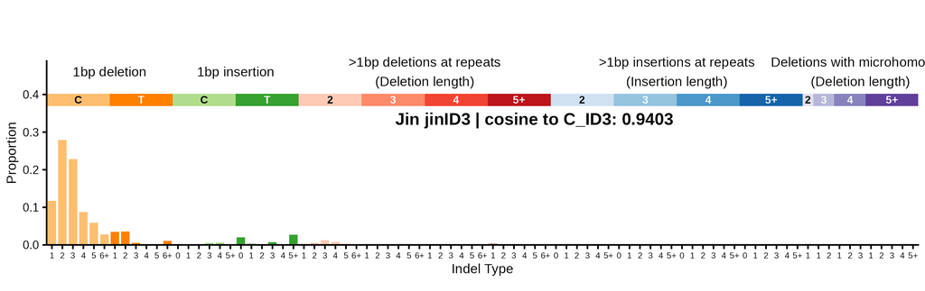